# BUA 455 Lecture 13 - Interactions Models

Penelope Pooler Eisenbies

2023-03-02

### Getting Started with Markdown

- Download Zipped R project
- Open Zipped folder and copy internal folder (R Project) to a BUA 345 folder on your computer NOT IN DOWLOADS
- Click on .Rproj file to open project
- Click on `code_data_output` file to open it.
- Click on `BUA_345_Lecture_13.Rmd` to open it.
- Run Setup Chunk

### Setup

- The setup chunk shows the packages needed for this demo.
- R will install specified packages if needed (only required once after R is installed)
- R will load specified packaged (required every time you start a new R session)
- The first time you run this code, R will install these packages which will be slow.
- **If you get warnings, that’s okay.**
- If you get **error messages**, I (or TA), can help you.

### Setup Chunk for Lecture 12

```r
# this line specifies options for default options for all R Chunks
knitr::opts_chunk$set(echo=T, highlight=T)

# suppress scientific notation
options(scipen=100)

# install helper package that loads and installs other packages, if needed
if (!require("pacman")) install.packages("pacman", repos = "http://lib.stat.cmu.edu/R/CRAN/")
# install and load required packages
pacman::p_load(pacman,tidyverse, magrittr, olsrr, gridExtra, ggiraphExtra, knitr)

# verify packages
p_loaded()
```

```
##  [1] "knitr"        "ggiraphExtra" "gridExtra"    "olsrr"        "magrittr"
##  [6] "forcats"      "stringr"      "dplyr"        "purrr"        "readr"
## [11] "tidyr"        "tibble"       "ggplot2"      "tidyverse"    "pacman"
```

**NOTES:

- ** Don’t worry about `xaringanthemer` package (required for my slides but not for your code).
- New Packages: `ggiraphExtra` and `knitr`

### Review Question - House Remodeling Data from Lecture 12

```r
house_remodel <- read_csv("house_remodel.csv", show_col_types = F) |>  # import data
  glimpse(width=75)
```

```
## Rows: 57
## Columns: 3
## $ Price       <dbl> 554000, 484000, 391000, 354000, 410000, 349000, 40900…
## $ Square_Feet <dbl> 2702, 2378, 1846, 1820, 1794, 1768, 1752, 1719, 1676,…
## $ Remodeled   <chr> "No", "No", "No", "No", "No", "No", "No", "No", "No",…
```

```r
house_remodel |> select(Remodeled) |> table()   # number of obs by category
```

```
## Remodeled
##  No Yes
##  29  28
```

```r
house_remodel |> select(Price, Square_Feet) |> cor() |> round(2)  # correlation of price & sq. ft.
```

```
##             Price Square_Feet
## Price        1.00        0.75
## Square_Feet  0.75        1.00
```

### Review of House Remodel Data - Parallel Lines Model

### Lecture 13 In-class Exercises

#### **Question 1 (L13) - Session ID: bua345s23**

Based on the `Parameter Estimates` table for the specified categorical regression model, which category is the baseline category?

```r
(house_rem_cat_ols<- ols_regress(Price ~ Square_Feet + Remodeled, data=house_remodel))
```

```
##                             Model Summary
## ----------------------------------------------------------------------
## R                       0.924       RMSE                    32958.534
## R-Squared               0.854       Coef. Var                   8.223
## Adj. R-Squared          0.848       MSE                1086264973.997
## Pred R-Squared          0.836       MAE                     28012.693
## ----------------------------------------------------------------------
##  RMSE: Root Mean Square Error
##  MSE: Mean Square Error
##  MAE: Mean Absolute Error
##
##                                       ANOVA
## ----------------------------------------------------------------------------------
##                         Sum of
##                        Squares        DF         Mean Square       F         Sig.
## ----------------------------------------------------------------------------------
## Regression    341892090457.686         2    170946045228.843     157.37    0.0000
## Residual       58658308595.823        54      1086264973.997
## Total         400550399053.509        56
## ----------------------------------------------------------------------------------
##
##                                          Parameter Estimates
## -----------------------------------------------------------------------------------------------------
##        model          Beta    Std. Error    Std. Beta      t        Sig          lower         upper
## -----------------------------------------------------------------------------------------------------
##  (Intercept)    137549.093     17620.447                  7.806    0.000    102222.224    172875.963
##  Square_Feet       137.879        10.836        0.670    12.725    0.000       116.155       159.602
## RemodeledYes     90917.216      8834.268        0.542    10.291    0.000     73205.575    108628.858
## -----------------------------------------------------------------------------------------------------
```

### A Quick Comment About Formatted Output

- In HW 6 and below I have used R coding to format the output to make it easier to read. The values are IDENTICAL to the unformatted output.
- The formatted output has different appearance in the slides and html file.

#### Formatted Output (Similar to HW 6)

| Model Term | Beta | Std. Error | t statistic | P-value |
| --- | --- | --- | --- | --- |
| (Intercept) | 137549.09 | 17620.45 | 7.81 | 0 |
| Square_Feet | 137.88 | 10.84 | 12.72 | 0 |
| RemodeledYes | 90917.22 | 8834.27 | 10.29 | 0 |

### Quick Review of Categorical Regression

- On Tuesday we covered the `Parallel Lines` Model:
  - A Parallel Lines model has two X variables, one quantitative and one categorical variable.
  - Model estimates a separate SLR model for each category in the categorical variable.
  - Model assumes all categories have the same **SLOPE**.
  - Model estimates a separate **INTERCEPT** for each category.
  - Model output shows results of a hypothesis test to determine if each non-baseline category’s intercept is significantly different from baseline intercept.

[interactive chart not shown]

### Calculations from Output Values and Interpretation

- By default R chooses baseline categories alphabetically
  - `No` is before `Yes` so un-`Remodeled` houses are the baseline
  - un-Remodeled SLR Model: `Est. Price = 137549.093 + 137.879 * Square_Feet`
  - Remodeled SLR Model:
    - `Est. Price = 137549.093 + 137.879 * Square_Feet + 90917.216`
    - `Est. Price = 137549.093 + 90917.216 + 137.879 * Square_Feet`
    - `Est. Price = _____ + 137.879 * Square_Feet`
- **Interpretation:**
  - Prices of remodeled houses are about *91 thousand dollars more than similar houses without remodeling*, after accounting for square footage.
  - This difference is statistically significant (P-value < 0.001)

### Import and Examine Celebrity Profession Data

```r
# import and examine celeb profession dataset
celeb_prof <- read_csv("celeb_prof.csv", show_col_types=F) |>
  glimpse(width=75)
```

```
## Rows: 16
## Columns: 4
## $ Celebrity  <chr> "Jim Parsons", "Johnny Depp", "Tom Cruise", "Leonardo …
## $ Earnings   <dbl> 29, 48, 53, 29, 61, 32, 36, 41, 81, 44, 70, 77, 68, 38…
## $ Age        <dbl> 44, 53, 55, 43, 62, 45, 49, 50, 29, 40, 32, 32, 35, 42…
## $ Profession <chr> "Actor", "Actor", "Actor", "Actor", "Actor", "Actor", …
```

```r
# use table to summarize data by category
celeb_prof |> select(Profession) |> table()
```

```
## Profession
##   Actor Athlete
##       8       8
```

### Examine Correlations in Data and within Each Category

- Note that if categories have different slopes, correlations for whole dataset will be misleading.

```r
# all data
celeb_prof |> select(Earnings, Age) |> cor() |> round(2)
```

```
##          Earnings   Age
## Earnings     1.00 -0.46
## Age         -0.46  1.00
```

```r
# actors only
celeb_prof |> filter(Profession=="Actor") |>
  select(Earnings, Age) |> cor() |> round(2)
```

```
##          Earnings  Age
## Earnings     1.00 0.99
## Age          0.99 1.00
```

```r
# athletes only
celeb_prof |> filter(Profession=="Athlete") |>
  select(Earnings, Age) |> cor() |> round(2)
```

```
##          Earnings   Age
## Earnings     1.00 -0.98
## Age         -0.98  1.00
```

### Explore and Plot Data

- Scatter plot shows that a regression model should be created with
  - Different intercepts for each profession
  - Different slopes for each profession

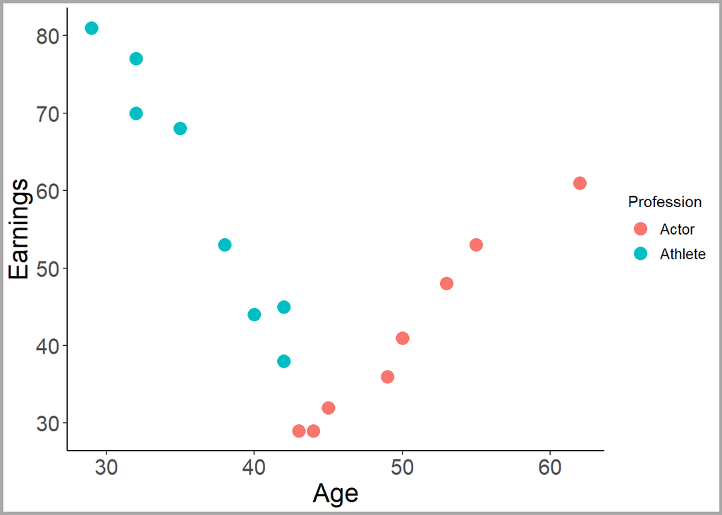

```r
(celeb_sctrplot <- celeb_prof |> #scatterplot code
  ggplot() +
  geom_point(aes(x=Age, y=Earnings, color=Profession), size=4) +
  theme_classic() +
  theme(axis.title = element_text(size=18),
        axis.text = element_text(size=15),
        legend.text = element_text(size=10),
        plot.background = element_rect(colour = "darkgrey", fill=NA, size=2)))
```

### Interactive Model Plot

- Model specified with interaction term:

  `Age*Profession`

```r
# create linear model with categories an interaction
celeb_prof_lm <-
  lm(Earnings ~ Age + Profession +
       Age*Profession, data=celeb_prof)

# create interactive plot of model
# copy and paste this into console (below) to see plot in viewer
(clb_int <- ggPredict(celeb_prof_lm,
                     interactive = T))
```

[interactive chart not shown]

### Regression Model

- Now that we understand the data and linear trends, we can examine and interpret the regression model output.

```r
# formatted regression output
# model is saved and printed to screen
(celeb_interaction_ols<- ols_regress(Earnings ~ Age + Profession + Age*Profession,
                                     data=celeb_prof, iterm = T))
```

```
##                         Model Summary
## -------------------------------------------------------------
## R                       0.987       RMSE               3.048
## R-Squared               0.974       Coef. Var          6.058
## Adj. R-Squared          0.967       MSE                9.291
## Pred R-Squared          0.951       MAE                2.265
## -------------------------------------------------------------
##  RMSE: Root Mean Square Error
##  MSE: Mean Square Error
##  MAE: Mean Absolute Error
##
##                                 ANOVA
## ---------------------------------------------------------------------
##                 Sum of
##                Squares        DF    Mean Square       F         Sig.
## ---------------------------------------------------------------------
## Regression    4131.949         3       1377.316    148.246    0.0000
## Residual       111.489        12          9.291
## Total         4243.438        15
## ---------------------------------------------------------------------
##
##                                          Parameter Estimates
## ------------------------------------------------------------------------------------------------------
##                 model       Beta    Std. Error    Std. Beta       t        Sig       lower      upper
## ------------------------------------------------------------------------------------------------------
##           (Intercept)    -50.297         9.054                  -5.555    0.000    -70.023    -30.571
##                   Age      1.824         0.179        0.983     10.170    0.000      1.433      2.215
##     ProfessionAthlete    227.218        12.389        0.263     18.340    0.000    200.224    254.212
## Age:ProfessionAthlete     -5.063         0.293       -1.487    -17.294    0.000     -5.701     -4.425
## ------------------------------------------------------------------------------------------------------
```

### Model Interpretation - Interpreting model coefficients (betas)

- **Baseline category is first alphabetically**
  - Actor comes before Athlete in the alphabet so **Actor is the baseline category**.
  - **Actor SLR Model: `Earnings = -50.297 + 1.824*Age`**
- **`ProfessionAthlete` term:** Difference from Actor (baseline) model Intercept
- **`Age:ProfessionAthlete` term:** Difference from Actor model Slope
  - Athlete SLR Model requires some calculations:
    - `Earnings = -50.297 + 1.824*Age + 227.218 - 5.063*Age`
    - `Earnings = (-50.297 + 227.218) + (1.824 - 5.063)*Age`
    - `Earnings = 176.921 - ____*Age`
    - *Athlete SLR Model:* `Earnings = 176.921 - ____*Age`

### Lecture 13 In-class Exercises

#### **Question 2 (L13) - Session ID: bua345s23**

- **What is the slope term (estimated `beta` for Age) for the Athlete SLR model?**
  - Specify answer to two decimal places.

#### Abridged Output

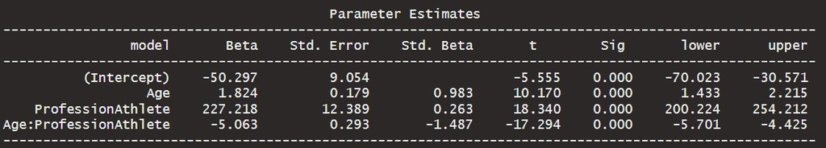

- **`ProfessionAthlete` term:** Difference from Actor (baseline) model Intercept
- **`Age:ProfessionAthlete` term:** Difference from Actor model Slope
  - `Earnings = (-50.297 + 227.218) + (1.824 - 5.063)*Age`
  - *Athlete SLR Model:* `Earnings = 176.921 - ____*Age`

### Determining Statistical Significance

- In this case, we don’t need to examine the P-values because the model differences between groups are so clear (but we will).
- The two intercepts and two slopes are **VERY** different.
- Reminder of Hypothesis Testing concepts:
  - **The SMALLER the P-value, the more evidence there is that the true value of Beta (model term) is not zero.**
  - If this sentence is not clear to you, **you are responsible for reviewing the Review Materials** on Hypothesis Tests and Significance Tests (and other related topics):
    - **[Review Materials Folder on Blackboard](https://blackboard.syracuse.edu/webapps/blackboard/content/listContentEditable.jsp?content_id=_8630674_1&course_id=_494704_1&mode=reset)**
    - **[Khan Academy - The Idea of Significance tests](https://www.khanacademy.org/math/statistics-probability/significance-tests-one-sample/idea-of-significance-tests/v/simple-hypothesis-testing)**
    - **[Khan Academy - Comparing a P-value to a Significance level](https://www.khanacademy.org/math/statistics-probability/significance-tests-one-sample/tests-about-population-mean/v/comparing-p-value-from-t-statistic-to-significance-level?modal=1)**
- **P-value for difference in intercepts (`ProfessionAthlete`):** < 0.001
  - Intercepts for Actors SLR model and Athletes SLR model are significantly different.
- **P-value for difference in slopes (`Age:ProfessionAthlete`):** < 0.001
- Slopes for Actors SLR model and Athletes SLR model are significantly different.
- **These interpretations are in agreement with what we can easily see in the Interactive Model Plot.**

### Movie Genres and Costs

- Is length of a movie (`Runtime`) a good predictor of the movie budget?
- Does the relationship between movie length and budget differ by movie genre?

#### Import Movie Data

```r
# Import and examine data
movies <- read_csv("movies.csv", show_col_types = F) |>
  glimpse(width=75)
```

```
## Rows: 20
## Columns: 4
## $ Movie   <chr> "Paranormal Activity 3", "The Others", "The Lincoln Lawye…
## $ Genre   <chr> "Suspense / Horror", "Suspense / Horror", "Suspense / Hor…
## $ Budget  <dbl> 5, 17, 40, 30, 37, 27, 25, 16, 85, 12, 195, 125, 140, 90,…
## $ Runtime <dbl> 83, 104, 118, 106, 114, 105, 99, 91, 168, 84, 148, 131, 1…
```

```r
# use table to examine categories in the data
movies |> select(Genre) |> table()
```

```
## Genre
##            Action Suspense / Horror
##                10                10
```

### Examine Correlations in Movie Data

- Again, if categories have different slopes, correlations for whole dataset will be misleading.

```r
# all data
movies |> select(Budget, Runtime) |> cor() |> round(2)
```

```
##         Budget Runtime
## Budget    1.00    0.76
## Runtime   0.76    1.00
```

```r
# actions movies only
movies |> filter(Genre == "Action") |>
  select(Budget, Runtime) |> cor() |> round(2)
```

```
##         Budget Runtime
## Budget    1.00    0.95
## Runtime   0.95    1.00
```

```r
# suspense/horror movies only
movies |> filter(Genre == "Suspense / Horror") |>
  select(Budget, Runtime) |> cor() |> round(2)
```

```
##         Budget Runtime
## Budget    1.00    0.99
## Runtime   0.99    1.00
```

### Explore and Plot Data

- Plot below clearly shows that a regression model should be created with
  - Different intercepts for each profession
  - Different slopes for each profession

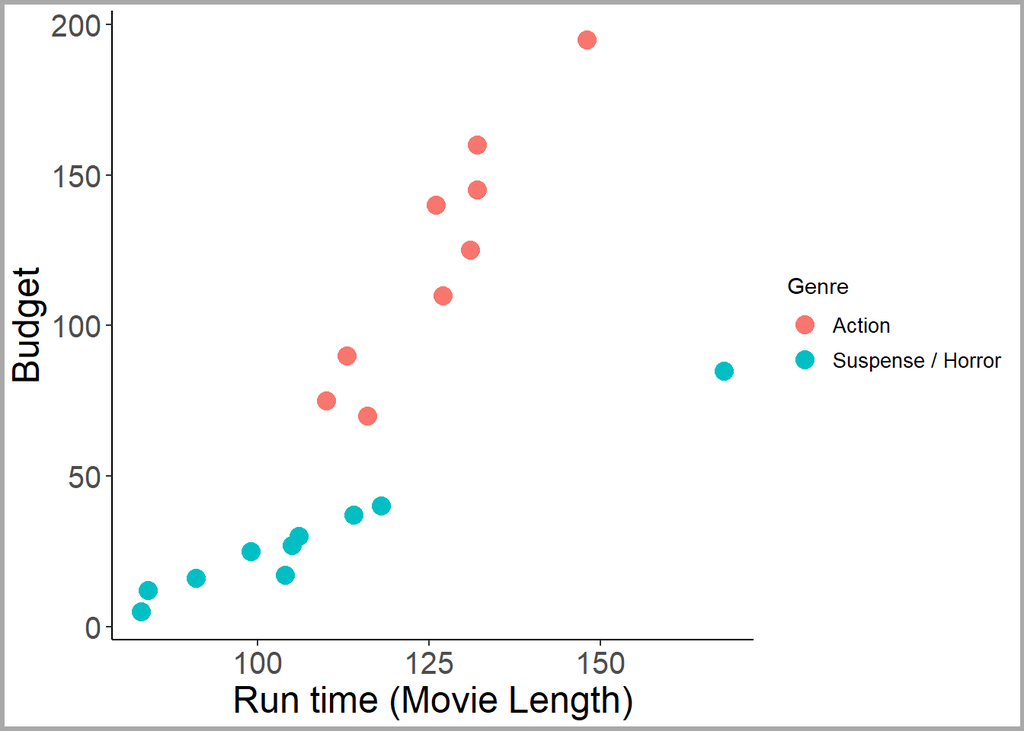

```r
(movie_scrtplot <- movies |>
  ggplot() +
  geom_point(aes(x=Runtime, y=Budget, color=Genre), size=4) +
  theme_classic() +
  labs(x="Run time (Movie Length)") +
  theme(axis.title = element_text(size=18),
        axis.text = element_text(size=15),
        legend.text = element_text(size=10),
        plot.background = element_rect(colour = "darkgrey", fill=NA, size=2)))
```

### Interactive Model Plot

- Model specified with interaction term:

  `Runtime*Genre`

```r
# create linear model with categories an interaction
movie_cat_lm <- lm(Budget ~ Runtime + Genre +
                     Runtime*Genre, data=movies)

# create interactive plot of model
# copy and paste this into console (below) to see plot in viewer
(movie_int <- ggPredict(movie_cat_lm,
          interactive = T))
```

[interactive chart not shown]

### Regression Model

- Again, we can examine and interpret the regression model output.

```r
# formatted regression output
# model is saved and printed to screen
(movie_interaction_ols<- ols_regress(Budget ~ Runtime + Genre +
                                       Runtime*Genre, data=movies, iterm = T))
```

```
##                          Model Summary
## ---------------------------------------------------------------
## R                       0.985       RMSE                10.403
## R-Squared               0.971       Coef. Var           14.068
## Adj. R-Squared          0.966       MSE                108.222
## Pred R-Squared          0.961       MAE                  6.446
## ---------------------------------------------------------------
##  RMSE: Root Mean Square Error
##  MSE: Mean Square Error
##  MAE: Mean Absolute Error
##
##                                 ANOVA
## ----------------------------------------------------------------------
##                  Sum of
##                 Squares        DF    Mean Square       F         Sig.
## ----------------------------------------------------------------------
## Regression    58283.403         3      19427.801    179.519    0.0000
## Residual       1731.547        16        108.222
## Total         60014.950        19
## ----------------------------------------------------------------------
##
##                                                Parameter Estimates
## -----------------------------------------------------------------------------------------------------------------
##                          model        Beta    Std. Error    Std. Beta      t        Sig        lower       upper
## -----------------------------------------------------------------------------------------------------------------
##                    (Intercept)    -286.671        35.527                 -8.069    0.000    -361.985    -211.356
##                        Runtime       3.254         0.284        1.200    11.454    0.000       2.652       3.857
##         GenreSuspense / Horror     218.755        38.812       -0.485     5.636    0.000     136.477     301.032
## Runtime:GenreSuspense / Horror      -2.347         0.318       -0.723    -7.382    0.000      -3.020      -1.673
## -----------------------------------------------------------------------------------------------------------------
```

### Lecture 13 In-class Exercises

#### **Question 3 (L13) - Session ID: bua345s23**

- **What is the intercept term (estimated `beta`) for the Suspense / Horror SLR model?**
  - Specify answer to two decimal places.

#### Abridged Output

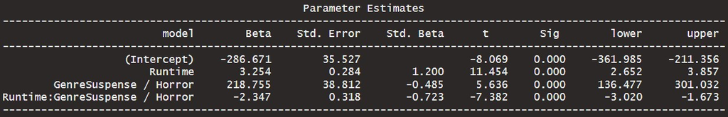

### Determining Statistical Significance

- In this case, we don’t need to examine the P-values because the model differences between groups are so clear (but we will).
- The two intercepts and two slopes are **VERY** different.
- Reminder of Hypothesis Testing concepts:
  - **The SMALLER the P-value, the more evidence there is that the true value of Beta (model term) is not zero.**
  - If this sentence is not clear to you, **you are responsible for reviewing the Review Materials** on Hypothesis Tests and Significance Tests (and other related topics):
    - **[Review Materials Folder on Blackboard](https://blackboard.syracuse.edu/webapps/blackboard/content/listContentEditable.jsp?content_id=_8630674_1&course_id=_494704_1&mode=reset)**
    - **[Khan Academy - The Idea of Significance tests](https://www.khanacademy.org/math/statistics-probability/significance-tests-one-sample/idea-of-significance-tests/v/simple-hypothesis-testing)**
    - **[Khan Academy - Comparing a P-value to a Significance level](https://www.khanacademy.org/math/statistics-probability/significance-tests-one-sample/tests-about-population-mean/v/comparing-p-value-from-t-statistic-to-significance-level?modal=1)**
- **P-value for difference in intercepts (`GenreSuspense / Horror`):** < 0.001
  - Intercepts for these two distinct genre SLR models are `_____` (Next Question).
- **P-value for difference in slopes (`Runtime:GenreSuspense / Horror term`):** < 0.001
- Slopes for for these two distinct genre SLR models are `_____` (Next Question).
- **These interpretations are in agreement with what we can easily see in the Interactive Model Plot.**

### Lecture 13 In-class Exercises

#### **Question 4 (L13) - Session ID: bua345s23**

The difference in intercepts and the difference in slopes between the model for `Action` movies and the model for `Suspense / Horror` movies are both `_____`.

#### **Question 5 (L13) - Session ID: bua345s23**

Recall that the cutoff for determining significance of a regression model term based on it’s P-value is 0.05.

Fill in the blank:

The smaller the P-value, the `_____` evidence there is that the Beta coefficient is non-zero and the term is useful to the model.

### HW 6 - Questions 7 - 16

- Dataset has three categories of Diamonds:
  - Colorless
  - Faint yellow
  - Nearly colorless
- **Colorless** is first alphabetically so that is the **baseline category** by default.
  - Each color category has unique intercept.
  - Each color category has a unique slope
  - The interactive model plot and abridged regression output are provided.
  - All Blackboard questions can be answered using provided `.html` output and verified using provided. interactive plot.

### Looking Ahead - What’s Next?

- This week, ALL of the categorical models we have covered could be simplified to multiple SLRs, with same or different slopes.
- ALL of the variables have had P-values less than 0.05 so the terms were all useful.
- **There are many many model options where these two facts are not true.**
- Time permitting, here’s a brief look at these `insurance` data which includes multiple explanatory variables:

```r
insurance <- read_csv("Insurance.csv", show_col_types=F) |>
  glimpse(width=75)
```

```
## Rows: 1,338
## Columns: 8
## $ Charges    <dbl> 16884.924, 1725.552, 4449.462, 21984.471, 3866.855, 37…
## $ ln_charges <dbl> 9.734176, 7.453302, 8.400538, 9.998092, 8.260197, 8.23…
## $ Age        <dbl> 19, 18, 28, 33, 32, 31, 46, 37, 37, 60, 25, 62, 23, 56…
## $ Sex        <chr> "female", "male", "male", "male", "male", "female", "f…
## $ BMI        <dbl> 27.900, 33.770, 33.000, 22.705, 28.880, 25.740, 33.440…
## $ Children   <dbl> 0, 1, 3, 0, 0, 0, 1, 3, 2, 0, 0, 0, 0, 0, 0, 1, 1, 0, …
## $ Smoker     <chr> "yes", "no", "no", "no", "no", "no", "no", "no", "no",…
## $ Region     <chr> "southwest", "southeast", "southeast", "northwest", "n…
```

### Variable and Model Selection

- There are 3 quantitative variables:
  - Age
  - BMI
  - Children
- There are 3 categorical variables:
  - Sex
  - Smoker
  - Region
- There are literally hundreds of possible models including interaction terms
- Note that an interaction can also be between two quantitative variables
- You can also have interaction terms with three variables (but I try to avoid those).
- How do we sort through all of the possible options?
  - Software helps us pare down all the possible models to a few choices.
  - The analyst then uses critical thinking and examination of the data to determine the final model.
- Variable and Model Selection methods are the next set of topics.

### **Key Points from Today**

- **Categorical Interaction Model**
  - Separate SLR for each group.
  - BOTH slopes and intercepts can differ by category
  - We can test if interaction term (slope difference) is significant.
- **Next Topics**
  - Comparing model goodness of fit
  - Introduction to variable selection
- HW 6 was posted yesterday and is due 3/7

You may submit an ‘Engagement Question’ about each lecture until midnight on the day of the lecture. **A minimum of four submissions are required during the semester.**